Work through the kaggle Titanic competition found [here](https://www.kaggle.com/c/titanic) with bagging, random forest, and GBM boosting.

## Libraries I might Use

```r
library(tidyverse)
library(class)
library(ISLR)
library(tidyverse)
library(randomForest)
library(gbm)
library(MASS)
library(rpart)
library(caTools)
```

## Loading in the Data

```r
train_data = read.csv("train.csv") # Train data Is really my sample overall
test_data = read.csv("test.csv") # New predictions will be performed on this data set
```

## Encoding Factors and forcing NA for char columns

```r
train_data[train_data==""] <- NA
train_data$Sex=factor(train_data$Sex, levels=c("male","female") ,labels = c(0,1))
train_data$Pclass=factor(train_data$Pclass, levels = c(1,2,3), labels = c(0,1,2))
train_data$Embarked=factor(train_data$Embarked, levels = c("C","Q","S"), labels = c(0,1,2))
train_data$Survived=factor(train_data$Survived)
train_data
```

| PassengerId | Survived | Pclass | Name | Sex | Age | SibSp | Parch | Ticket | Fare | Cabin | Embarked |
| --- | --- | --- | --- | --- | --- | --- | --- | --- | --- | --- | --- |
| 1 | 0 | 2 | Braund, Mr. Owen Harris | 0 | 22.00 | 1 | 0 | A/5 21171 | 7.2500 | NA | 2 |
| 2 | 1 | 0 | Cumings, Mrs. John Bradley (Florence Briggs Thayer) | 1 | 38.00 | 1 | 0 | PC 17599 | 71.2833 | C85 | 0 |
| 3 | 1 | 2 | Heikkinen, Miss. Laina | 1 | 26.00 | 0 | 0 | STON/O2. 3101282 | 7.9250 | NA | 2 |
| 4 | 1 | 0 | Futrelle, Mrs. Jacques Heath (Lily May Peel) | 1 | 35.00 | 1 | 0 | 113803 | 53.1000 | C123 | 2 |
| 5 | 0 | 2 | Allen, Mr. William Henry | 0 | 35.00 | 0 | 0 | 373450 | 8.0500 | NA | 2 |
| 6 | 0 | 2 | Moran, Mr. James | 0 | NA | 0 | 0 | 330877 | 8.4583 | NA | 1 |
| 7 | 0 | 0 | McCarthy, Mr. Timothy J | 0 | 54.00 | 0 | 0 | 17463 | 51.8625 | E46 | 2 |
| 8 | 0 | 2 | Palsson, Master. Gosta Leonard | 0 | 2.00 | 3 | 1 | 349909 | 21.0750 | NA | 2 |
| 9 | 1 | 2 | Johnson, Mrs. Oscar W (Elisabeth Vilhelmina Berg) | 1 | 27.00 | 0 | 2 | 347742 | 11.1333 | NA | 2 |
| 10 | 1 | 1 | Nasser, Mrs. Nicholas (Adele Achem) | 1 | 14.00 | 1 | 0 | 237736 | 30.0708 | NA | 0 |

[output cut: 881 more lines]

# Exploring the data

```r
train_data
```

| PassengerId | Survived | Pclass | Name | Sex | Age | SibSp | Parch | Ticket | Fare | Cabin | Embarked |
| --- | --- | --- | --- | --- | --- | --- | --- | --- | --- | --- | --- |
| 1 | 0 | 2 | Braund, Mr. Owen Harris | 0 | 22.00 | 1 | 0 | A/5 21171 | 7.2500 | NA | 2 |
| 2 | 1 | 0 | Cumings, Mrs. John Bradley (Florence Briggs Thayer) | 1 | 38.00 | 1 | 0 | PC 17599 | 71.2833 | C85 | 0 |
| 3 | 1 | 2 | Heikkinen, Miss. Laina | 1 | 26.00 | 0 | 0 | STON/O2. 3101282 | 7.9250 | NA | 2 |
| 4 | 1 | 0 | Futrelle, Mrs. Jacques Heath (Lily May Peel) | 1 | 35.00 | 1 | 0 | 113803 | 53.1000 | C123 | 2 |
| 5 | 0 | 2 | Allen, Mr. William Henry | 0 | 35.00 | 0 | 0 | 373450 | 8.0500 | NA | 2 |
| 6 | 0 | 2 | Moran, Mr. James | 0 | NA | 0 | 0 | 330877 | 8.4583 | NA | 1 |
| 7 | 0 | 0 | McCarthy, Mr. Timothy J | 0 | 54.00 | 0 | 0 | 17463 | 51.8625 | E46 | 2 |
| 8 | 0 | 2 | Palsson, Master. Gosta Leonard | 0 | 2.00 | 3 | 1 | 349909 | 21.0750 | NA | 2 |
| 9 | 1 | 2 | Johnson, Mrs. Oscar W (Elisabeth Vilhelmina Berg) | 1 | 27.00 | 0 | 2 | 347742 | 11.1333 | NA | 2 |
| 10 | 1 | 1 | Nasser, Mrs. Nicholas (Adele Achem) | 1 | 14.00 | 1 | 0 | 237736 | 30.0708 | NA | 0 |

[output cut: 881 more lines]

```r
summary(train_data)
```

```
  PassengerId    Survived Pclass      Name           Sex          Age            SibSp           Parch           Ticket               Fare
 Min.   :  1.0   0:549    0:216   Length:891         0:577   Min.   : 0.42   Min.   :0.000   Min.   :0.0000   Length:891         Min.   :  0.00
 1st Qu.:223.5   1:342    1:184   Class :character   1:314   1st Qu.:20.12   1st Qu.:0.000   1st Qu.:0.0000   Class :character   1st Qu.:  7.91
 Median :446.0            2:491   Mode  :character           Median :28.00   Median :0.000   Median :0.0000   Mode  :character   Median : 14.45
 Mean   :446.0                                               Mean   :29.70   Mean   :0.523   Mean   :0.3816                      Mean   : 32.20
 3rd Qu.:668.5                                               3rd Qu.:38.00   3rd Qu.:1.000   3rd Qu.:0.0000                      3rd Qu.: 31.00
 Max.   :891.0                                               Max.   :80.00   Max.   :8.000   Max.   :6.0000                      Max.   :512.33
                                                             NA's   :177
    Cabin           Embarked
 Length:891         0   :168
 Class :character   1   : 77
 Mode  :character   2   :644
                    NA's:  2
```

1. I’m predicting Survived
2. Intuitively, I’d expect Pclass to be a significant predictor
3. Likewise, don’t women and children always go first? So age and sex should be valuable predictors.
4. SibSp represents the number of siblings/spouses aboard. Maybe important? If there are people with you they might help you escape, but you might also stay behind for them.
5. Parch is the number of parents or children abboard. If you are young I’d expect higher number of parents increases your chance, while if you are older the number of children might cause you to hold back trying to help them.
6. Information in fare is probably contained in class
7. Cabin/Ticket seem unlikely to provide much meaningful information
8. embarked is the port of embarkation. Unlikely to help much, but I’m not that confident about it.

All told our big factors are pclass, age, sex, sibsp, parch. Maybe embarked.

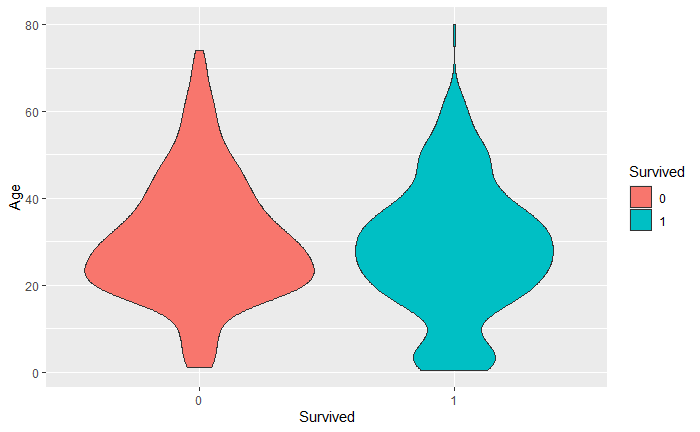

```r
ggplot(train_data)+
  geom_violin(aes(x=Survived, y = Age, fill = Survived))
```

Right away we are reminded of 177 missing age values seen inthe summary.

We can also see that the didnt survive group has has a heavier weight around the age of 25.

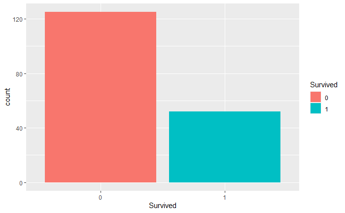

```r
ggplot(train_data[which(is.na(train_data$Age)),])+
  geom_bar(aes(x=Survived, fill = Survived))
```

Most of our missing values died

```r
train_data[which(is.na(train_data$Age)),]
```

|  | PassengerId | Survived | Pclass | Name | Sex | Age | SibSp | Parch | Ticket | Fare | Cabin | Embarked |
| --- | --- | --- | --- | --- | --- | --- | --- | --- | --- | --- | --- | --- |
| 6 | 6 | 0 | 2 | Moran, Mr. James | 0 | NA | 0 | 0 | 330877 | 8.4583 | NA | 1 |
| 18 | 18 | 1 | 1 | Williams, Mr. Charles Eugene | 0 | NA | 0 | 0 | 244373 | 13.0000 | NA | 2 |
| 20 | 20 | 1 | 2 | Masselmani, Mrs. Fatima | 1 | NA | 0 | 0 | 2649 | 7.2250 | NA | 0 |
| 27 | 27 | 0 | 2 | Emir, Mr. Farred Chehab | 0 | NA | 0 | 0 | 2631 | 7.2250 | NA | 0 |
| 29 | 29 | 1 | 2 | O'Dwyer, Miss. Ellen "Nellie" | 1 | NA | 0 | 0 | 330959 | 7.8792 | NA | 1 |
| 30 | 30 | 0 | 2 | Todoroff, Mr. Lalio | 0 | NA | 0 | 0 | 349216 | 7.8958 | NA | 2 |
| 32 | 32 | 1 | 0 | Spencer, Mrs. William Augustus (Marie Eugenie) | 1 | NA | 1 | 0 | PC 17569 | 146.5208 | B78 | 0 |
| 33 | 33 | 1 | 2 | Glynn, Miss. Mary Agatha | 1 | NA | 0 | 0 | 335677 | 7.7500 | NA | 1 |
| 37 | 37 | 1 | 2 | Mamee, Mr. Hanna | 0 | NA | 0 | 0 | 2677 | 7.2292 | NA | 0 |
| 43 | 43 | 0 | 2 | Kraeff, Mr. Theodor | 0 | NA | 0 | 0 | 349253 | 7.8958 | NA | 0 |

[output cut: 167 more lines]

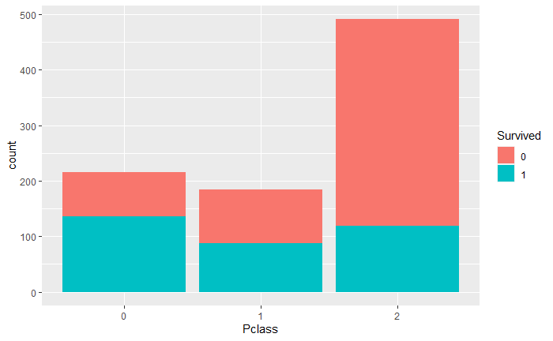

```r
ggplot(train_data)+
  geom_bar(aes(x=Pclass, fill = Survived))
```

Ticket class breakdown is as you would expect.

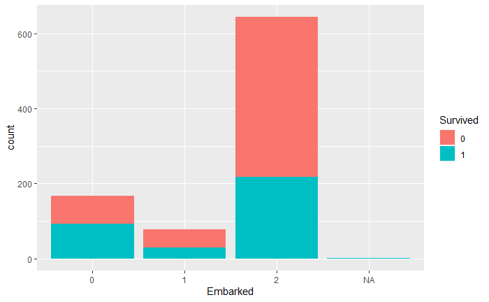

```r
ggplot(train_data)+
  geom_bar(aes(x=Embarked, fill = Survived))
```

There is more infromation that you would expect here. the final port of embarkation (southhampton) had the most people, but it also has the worst percentage of survival.

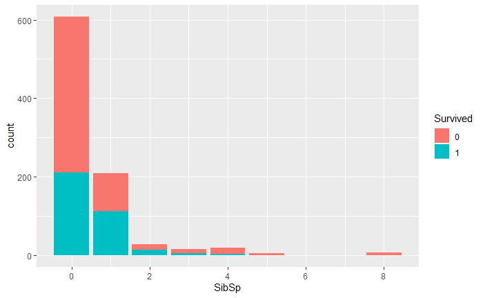

```r
ggplot(train_data)+
  geom_bar(aes(x=SibSp, fill = Survived))
```

Most people had 0 spouses or siblings aboard, the better percentage at 1 could be attributed directly to spouse, but that doesn’t hold up for the better percentage at 2

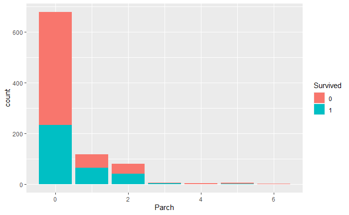

```r
ggplot(train_data)+
  geom_bar(aes(x=Parch, fill = Survived))
```

Increased survival at 1, 2, and 3. 1 and 2 are most likely being weighted by parents. 3 is interesting.

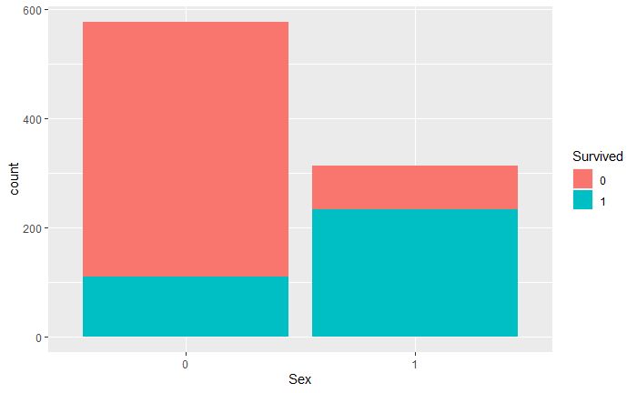

```r
ggplot(train_data)+
  geom_bar(aes(x=Sex, fill = Survived))
```

Women survived at a MUCH higher rate.

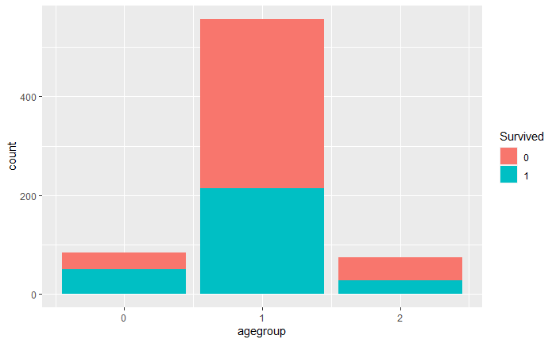

```r
train_data$agegroup = ifelse(train_data$Age < 16, 0, ifelse(train_data$Age < 50, 1, 2))
ggplot(train_data)+
 geom_bar(aes(x=agegroup, fill = Survived))
```

Children survive, those > 50 hardly do.

# Dealing with Missing Values

Now that we have explored the data, lets deal with the missing values in embarked and age. We will be using survival, pclass, sex, age, sibsp, parch, and embarked to predict the others

```r
clean_data = train_data[,c(2,3,5,6,7,8, 12)]
clean_data
```

| Survived | Pclass | Sex | Age | SibSp | Parch | Embarked |
| --- | --- | --- | --- | --- | --- | --- |
| 0 | 2 | 0 | 22.00 | 1 | 0 | 2 |
| 1 | 0 | 1 | 38.00 | 1 | 0 | 0 |
| 1 | 2 | 1 | 26.00 | 0 | 0 | 2 |
| 1 | 0 | 1 | 35.00 | 1 | 0 | 2 |
| 0 | 2 | 0 | 35.00 | 0 | 0 | 2 |
| 0 | 2 | 0 | NA | 0 | 0 | 1 |
| 0 | 0 | 0 | 54.00 | 0 | 0 | 2 |
| 0 | 2 | 0 | 2.00 | 3 | 1 | 2 |
| 1 | 2 | 1 | 27.00 | 0 | 2 | 2 |
| 1 | 1 | 1 | 14.00 | 1 | 0 | 0 |

[output cut: 881 more lines]

## Embarked

```r
clean_data_embarked = clean_data[-which(is.na(train_data$Embarked)),]
clean_data_embarked
```

|  | Survived | Pclass | Sex | Age | SibSp | Parch | Embarked |
| --- | --- | --- | --- | --- | --- | --- | --- |
| 1 | 0 | 2 | 0 | 22.00 | 1 | 0 | 2 |
| 2 | 1 | 0 | 1 | 38.00 | 1 | 0 | 0 |
| 3 | 1 | 2 | 1 | 26.00 | 0 | 0 | 2 |
| 4 | 1 | 0 | 1 | 35.00 | 1 | 0 | 2 |
| 5 | 0 | 2 | 0 | 35.00 | 0 | 0 | 2 |
| 6 | 0 | 2 | 0 | NA | 0 | 0 | 1 |
| 7 | 0 | 0 | 0 | 54.00 | 0 | 0 | 2 |
| 8 | 0 | 2 | 0 | 2.00 | 3 | 1 | 2 |
| 9 | 1 | 2 | 1 | 27.00 | 0 | 2 | 2 |
| 10 | 1 | 1 | 1 | 14.00 | 1 | 0 | 0 |

[output cut: 879 more lines]

### Test/Train Split

```r
set.seed(1234)
split = sample.split(clean_data_embarked$Survived, SplitRatio = 0.8)
train = subset(clean_data_embarked, split == TRUE)
test = subset(clean_data_embarked, split == FALSE)
```

### Model

```r
set.seed(1234)
rf.Embarked = randomForest(Embarked~Survived + Pclass+Sex+SibSp+Parch, data = clean_data_embarked,importance =TRUE, mtry = 3)
importance(rf.Embarked)
```

```
                  0         1          2 MeanDecreaseAccuracy MeanDecreaseGini
Survived  0.1761412 23.926388 -0.7525674             10.47326         9.088543
Pclass   29.7102029 20.917772 17.0280234             33.91091        28.531706
Sex       1.1353457 25.138247  3.6891944             14.49255         9.606021
SibSp     5.0916546  3.144096  9.8194733             12.15916        18.989624
Parch     4.9348200 19.201793 16.3263343             21.33507        18.814807
```

```r
yhat.Embarked = predict(rf.Embarked,newdata=test, type="response")
confusion_matrix = table(test$Embarked,yhat.Embarked)
confusion_matrix
```

```
   yhat.Embarked
      0   1   2
  0  15   0  23
  1   0   7   9
  2   6   1 117
```

```r
124/(121+16+30+2+3)
```

```
[1] 0.7209302
```

Not great predictive power, but basically we only are replacing two values. (with 2 most likely) I could do more here by looking at other predictors that ARE probably predictive of location like fare and ticket, but for the sake of time I’m just going to leave it at embarkation = 2

```r
train_data$Embarked[which(is.na(train_data$Embarked))] = 2
clean_data$Embarked[which(is.na(clean_data$Embarked))] = 2
```

## Age

```r
clean_data_age = clean_data[-which(is.na(train_data$Age)),]
clean_data_age = clean_data_age[,-1] #Can't use survived here because OG test set doesn't tell me survived.
clean_data_age
```

|  | Pclass | Sex | Age | SibSp | Parch | Embarked |
| --- | --- | --- | --- | --- | --- | --- |
| 1 | 2 | 0 | 22.00 | 1 | 0 | 2 |
| 2 | 0 | 1 | 38.00 | 1 | 0 | 0 |
| 3 | 2 | 1 | 26.00 | 0 | 0 | 2 |
| 4 | 0 | 1 | 35.00 | 1 | 0 | 2 |
| 5 | 2 | 0 | 35.00 | 0 | 0 | 2 |
| 7 | 0 | 0 | 54.00 | 0 | 0 | 2 |
| 8 | 2 | 0 | 2.00 | 3 | 1 | 2 |
| 9 | 2 | 1 | 27.00 | 0 | 2 | 2 |
| 10 | 1 | 1 | 14.00 | 1 | 0 | 0 |
| 11 | 2 | 1 | 4.00 | 1 | 1 | 2 |

[output cut: 704 more lines]

### Test/Train Split

```r
set.seed(1234)
split = sample.split(clean_data_age$Age, SplitRatio = 0.8)
train = subset(clean_data_age, split == TRUE)
test = subset(clean_data_age, split == FALSE)
```

### Model

```r
set.seed(1234)
rf.Age = randomForest(Age~., data = clean_data_age,importance =TRUE, mtry = 4)
importance(rf.Age)
```

```
           %IncMSE IncNodePurity
Pclass   87.248524     21086.175
Sex      16.198176      5410.003
SibSp    34.869585     15898.640
Parch    53.452846     21110.849
Embarked  9.446469      5809.567
```

```r
yhat.Age = predict(rf.Age,newdata=test)
mean((yhat.Age-test$Age)^2)
```

```
[1] 110.6331
```

ooooph that is a a not great mean squared error, but lets keep rolling with it for now.

```r
clean_data$Age[which(is.na(clean_data$Age))] = predict(rf.Age, newdata = clean_data[which(is.na(clean_data$Age)),])
train_data$Age[which(is.na(train_data$Age))] = predict(rf.Age, newdata = train_data[which(is.na(train_data$Age)),])
```

# Modedl Building

```r
clean_data
```

| Survived | Pclass | Sex | Age | SibSp | Parch | Embarked |
| --- | --- | --- | --- | --- | --- | --- |
| 0 | 2 | 0 | 22.000000 | 1 | 0 | 2 |
| 1 | 0 | 1 | 38.000000 | 1 | 0 | 0 |
| 1 | 2 | 1 | 26.000000 | 0 | 0 | 2 |
| 1 | 0 | 1 | 35.000000 | 1 | 0 | 2 |
| 0 | 2 | 0 | 35.000000 | 0 | 0 | 2 |
| 0 | 2 | 0 | 36.893599 | 0 | 0 | 1 |
| 0 | 0 | 0 | 54.000000 | 0 | 0 | 2 |
| 0 | 2 | 0 | 2.000000 | 3 | 1 | 2 |
| 1 | 2 | 1 | 27.000000 | 0 | 2 | 2 |
| 1 | 1 | 1 | 14.000000 | 1 | 0 | 0 |

[output cut: 881 more lines]

```r
set.seed(1234)
split = sample.split(clean_data$Survived, SplitRatio = 0.8)
train = subset(clean_data, split == TRUE)
test = subset(clean_data, split == FALSE)
```

```r
rf.Survived = randomForest(Survived~., data = train,importance =TRUE)
yhat.Survived = predict(rf.Survived,newdata=test, type="response")
confusion_matrix = table(test$Survived,yhat.Survived)
confusion_matrix
```

```
   yhat.Survived
     0  1
  0 92 18
  1 20 48
```

```r
140/178
```

```
[1] 0.7865169
```

not bad, but how does it compare to gender?

```r
yhat.gender = ifelse(test$Sex == 1, 1, 0)
confusion_matrix = table(test$Survived,yhat.gender)
confusion_matrix
```

```
   yhat.gender
     0  1
  0 89 21
  1 21 47
```

```r
136/178
```

```
[1] 0.7640449
```

Better, but not THAT much better. Let’s go ahead and clean up the test data and submit

# Test Data Cleanup

```r
test_data
```

| PassengerId | Pclass | Name | Sex | Age | SibSp | Parch | Ticket | Fare | Cabin | Embarked |
| --- | --- | --- | --- | --- | --- | --- | --- | --- | --- | --- |
| 892 | 3 | Kelly, Mr. James | male | 34.50 | 0 | 0 | 330911 | 7.8292 |  | Q |
| 893 | 3 | Wilkes, Mrs. James (Ellen Needs) | female | 47.00 | 1 | 0 | 363272 | 7.0000 |  | S |
| 894 | 2 | Myles, Mr. Thomas Francis | male | 62.00 | 0 | 0 | 240276 | 9.6875 |  | Q |
| 895 | 3 | Wirz, Mr. Albert | male | 27.00 | 0 | 0 | 315154 | 8.6625 |  | S |
| 896 | 3 | Hirvonen, Mrs. Alexander (Helga E Lindqvist) | female | 22.00 | 1 | 1 | 3101298 | 12.2875 |  | S |
| 897 | 3 | Svensson, Mr. Johan Cervin | male | 14.00 | 0 | 0 | 7538 | 9.2250 |  | S |
| 898 | 3 | Connolly, Miss. Kate | female | 30.00 | 0 | 0 | 330972 | 7.6292 |  | Q |
| 899 | 2 | Caldwell, Mr. Albert Francis | male | 26.00 | 1 | 1 | 248738 | 29.0000 |  | S |
| 900 | 3 | Abrahim, Mrs. Joseph (Sophie Halaut Easu) | female | 18.00 | 0 | 0 | 2657 | 7.2292 |  | C |
| 901 | 3 | Davies, Mr. John Samuel | male | 21.00 | 2 | 0 | A/4 48871 | 24.1500 |  | S |

[output cut: 408 more lines]

```r
test_data
```

| PassengerId | Pclass | Name | Sex | Age | SibSp | Parch | Ticket | Fare | Cabin | Embarked |
| --- | --- | --- | --- | --- | --- | --- | --- | --- | --- | --- |
| 892 | 3 | Kelly, Mr. James | male | 34.50 | 0 | 0 | 330911 | 7.8292 |  | Q |
| 893 | 3 | Wilkes, Mrs. James (Ellen Needs) | female | 47.00 | 1 | 0 | 363272 | 7.0000 |  | S |
| 894 | 2 | Myles, Mr. Thomas Francis | male | 62.00 | 0 | 0 | 240276 | 9.6875 |  | Q |
| 895 | 3 | Wirz, Mr. Albert | male | 27.00 | 0 | 0 | 315154 | 8.6625 |  | S |
| 896 | 3 | Hirvonen, Mrs. Alexander (Helga E Lindqvist) | female | 22.00 | 1 | 1 | 3101298 | 12.2875 |  | S |
| 897 | 3 | Svensson, Mr. Johan Cervin | male | 14.00 | 0 | 0 | 7538 | 9.2250 |  | S |
| 898 | 3 | Connolly, Miss. Kate | female | 30.00 | 0 | 0 | 330972 | 7.6292 |  | Q |
| 899 | 2 | Caldwell, Mr. Albert Francis | male | 26.00 | 1 | 1 | 248738 | 29.0000 |  | S |
| 900 | 3 | Abrahim, Mrs. Joseph (Sophie Halaut Easu) | female | 18.00 | 0 | 0 | 2657 | 7.2292 |  | C |
| 901 | 3 | Davies, Mr. John Samuel | male | 21.00 | 2 | 0 | A/4 48871 | 24.1500 |  | S |

[output cut: 408 more lines]

```r
test_data$Sex=factor(test_data$Sex, levels=c("male","female") ,labels = c(0,1))
test_data$Pclass=factor(test_data$Pclass, levels = c(1,2,3), labels = c(0,1,2))
test_data$Embarked=factor(test_data$Embarked, levels = c("C","Q","S"), labels = c(0,1,2))
test_data_clean = test_data[,c(2,4,5,6,7,11)]
test_data_clean
```

| Pclass | Sex | Age | SibSp | Parch | Embarked |
| --- | --- | --- | --- | --- | --- |
| 2 | 0 | 34.50 | 0 | 0 | 1 |
| 2 | 1 | 47.00 | 1 | 0 | 2 |
| 1 | 0 | 62.00 | 0 | 0 | 1 |
| 2 | 0 | 27.00 | 0 | 0 | 2 |
| 2 | 1 | 22.00 | 1 | 1 | 2 |
| 2 | 0 | 14.00 | 0 | 0 | 2 |
| 2 | 1 | 30.00 | 0 | 0 | 1 |
| 1 | 0 | 26.00 | 1 | 1 | 2 |
| 2 | 1 | 18.00 | 0 | 0 | 0 |
| 2 | 0 | 21.00 | 2 | 0 | 2 |

[output cut: 408 more lines]

```r
summary(test_data_clean)
```

```
 Pclass  Sex          Age            SibSp            Parch        Embarked
 0:107   0:266   Min.   : 0.17   Min.   :0.0000   Min.   :0.0000   0:102
 1: 93   1:152   1st Qu.:21.00   1st Qu.:0.0000   1st Qu.:0.0000   1: 46
 2:218           Median :27.00   Median :0.0000   Median :0.0000   2:270
                 Mean   :30.27   Mean   :0.4474   Mean   :0.3923
                 3rd Qu.:39.00   3rd Qu.:1.0000   3rd Qu.:0.0000
                 Max.   :76.00   Max.   :8.0000   Max.   :9.0000
                 NA's   :86
```

Only missing values in Age

```r
test_data_clean$Age[which(is.na(test_data_clean$Age))]=predict(rf.Age,test_data_clean[which(is.na(test_data_clean$Age)),])
```

```r
test_data_clean
```

| Pclass | Sex | Age | SibSp | Parch | Embarked |
| --- | --- | --- | --- | --- | --- |
| 2 | 0 | 34.50000 | 0 | 0 | 1 |
| 2 | 1 | 47.00000 | 1 | 0 | 2 |
| 1 | 0 | 62.00000 | 0 | 0 | 1 |
| 2 | 0 | 27.00000 | 0 | 0 | 2 |
| 2 | 1 | 22.00000 | 1 | 1 | 2 |
| 2 | 0 | 14.00000 | 0 | 0 | 2 |
| 2 | 1 | 30.00000 | 0 | 0 | 1 |
| 1 | 0 | 26.00000 | 1 | 1 | 2 |
| 2 | 1 | 18.00000 | 0 | 0 | 0 |
| 2 | 0 | 21.00000 | 2 | 0 | 2 |

[output cut: 408 more lines]

```r
predict(rf.Survived,test_data_clean)
```

```
  1   2   3   4   5   6   7   8   9  10  11  12  13  14  15  16  17  18  19  20  21  22  23  24  25  26  27  28  29  30  31  32  33  34  35  36  37  38  39
  0   0   0   0   0   0   0   0   1   0   0   0   1   0   1   1   0   0   0   0   0   1   1   0   1   0   1   0   0   0   0   0   0   0   0   0   0   1   0
 40  41  42  43  44  45  46  47  48  49  50  51  52  53  54  55  56  57  58  59  60  61  62  63  64  65  66  67  68  69  70  71  72  73  74  75  76  77  78
  0   0   0   0   1   1   0   0   0   1   0   0   0   1   1   0   0   0   0   0   1   0   0   0   1   1   1   1   0   0   1   1   0   0   0   1   0   0   1
 79  80  81  82  83  84  85  86  87  88  89  90  91  92  93  94  95  96  97  98  99 100 101 102 103 104 105 106 107 108 109 110 111 112 113 114 115 116 117
  0   1   1   0   0   0   0   0   1   0   1   1   0   0   1   0   0   0   1   0   0   0   1   0   0   0   1   0   0   0   0   0   0   1   1   1   1   0   0
118 119 120 121 122 123 124 125 126 127 128 129 130 131 132 133 134 135 136 137 138 139 140 141 142 143 144 145 146 147 148 149 150 151 152 153 154 155 156
  1   0   1   1   0   1   0   0   1   0   1   0   0   0   0   0   0   0   0   0   0   0   0   0   1   0   0   0   0   0   0   0   0   1   0   0   0   0   0
157 158 159 160 161 162 163 164 165 166 167 168 169 170 171 172 173 174 175 176 177 178 179 180 181 182 183 184 185 186 187 188 189 190 191 192 193 194 195
  1   0   0   1   1   1   1   0   0   0   0   0   1   0   0   0   0   0   0   1   1   0   1   1   0   0   1   0   1   0   1   0   0   0   0   0   0   0   1
196 197 198 199 200 201 202 203 204 205 206 207 208 209 210 211 212 213 214 215 216 217 218 219 220 221 222 223 224 225 226 227 228 229 230 231 232 233 234
  0   1   0   0   0   1   1   1   1   0   0   0   0   1   0   0   0   0   1   0   0   1   0   1   0   1   0   1   0   1   1   0   1   0   0   0   1   0   0
235 236 237 238 239 240 241 242 243 244 245 246 247 248 249 250 251 252 253 254 255 256 257 258 259 260 261 262 263 264 265 266 267 268 269 270 271 272 273
  0   0   0   0   1   1   1   1   0   0   0   0   1   0   1   0   1   0   1   0   0   0   0   0   1   0   0   0   1   1   0   0   0   0   0   0   0   0   1
274 275 276 277 278 279 280 281 282 283 284 285 286 287 288 289 290 291 292 293 294 295 296 297 298 299 300 301 302 303 304 305 306 307 308 309 310 311 312
  1   0   1   0   0   0   0   0   1   1   0   1   0   0   0   0   0   0   0   0   0   0   0   1   0   0   0   0   0   0   0   1   1   1   1   0   0   0   0
313 314 315 316 317 318 319 320 321 322 323 324 325 326 327 328 329 330 331 332 333 334 335 336 337 338 339 340 341 342 343 344 345 346 347 348 349 350 351
  0   0   1   1   0   0   0   0   0   0   0   0   1   0   1   0   0   0   1   0   0   1   0   0   0   0   0   0   0   0   0   1   0   0   0   0   0   1   1
352 353 354 355 356 357 358 359 360 361 362 363 364 365 366 367 368 369 370 371 372 373 374 375 376 377 378 379 380 381 382 383 384 385 386 387 388 389 390
  0   0   0   1   0   1   0   0   0   0   1   1   0   1   0   0   0   1   0   0   1   0   0   1   1   0   0   0   0   0   0   0   0   0   1   0   0   0   0
391 392 393 394 395 396 397 398 399 400 401 402 403 404 405 406 407 408 409 410 411 412 413 414 415 416 417 418
  0   1   0   0   0   1   0   1   0   0   1   0   1   0   0   0   0   0   1   1   1   1   0   0   1   0   0   1
Levels: 0 1
```

```r
Rfguess = data.frame(test_data$PassengerId, predict(rf.Survived,test_data_clean))
colnames(Rfguess) <- c("PassengerId","Survived")
Rfguess
```

|  | PassengerId | Survived |
| --- | --- | --- |
| 1 | 892 | 0 |
| 2 | 893 | 0 |
| 3 | 894 | 0 |
| 4 | 895 | 0 |
| 5 | 896 | 0 |
| 6 | 897 | 0 |
| 7 | 898 | 0 |
| 8 | 899 | 0 |
| 9 | 900 | 1 |
| 10 | 901 | 0 |

[output cut: 408 more lines]

```r
write.csv(Rfguess, "rfguess.csv",row.names = FALSE)
```

Final score: 0.77751, not great but I’m in the top quarter and improved over the gender guesses at least!

```r
bagged.Survived = randomForest(Survived~., data = train,importance =TRUE, mtry = 6)
yhat.Survived = predict(bagged.Survived,newdata=test, type="response")
confusion_matrix = table(test$Survived,yhat.Survived)
confusion_matrix
```

```
   yhat.Survived
     0  1
  0 87 23
  1 19 49
```

```r
110/188
```

```
[1] 0.5851064
```

```r
Baggedguess = data.frame(test_data$PassengerId, predict(bagged.Survived,test_data_clean))
colnames(Baggedguess) <- c("PassengerId","Survived")
write.csv(Baggedguess, "rfguess.csv",row.names = FALSE)
```

```r
boost.Survived = gbm(as.character(Survived)~., data = train, distribution="bernoulli", n.tree = 5000)
best.iter <- gbm.perf(boost.Survived, method = "OOB", plot = FALSE)
```

```
OOB generally underestimates the optimal number of iterations although predictive performance is reasonably competitive. Using cv_folds>1 when calling gbm usually results in improved predictive performance.
```

```r
best.iter
```

```
[1] 92
attr(,"smoother")
Call:
loess(formula = object$oobag.improve ~ x, enp.target = min(max(4,
    length(x)/10), 50))

Number of Observations: 5000
Equivalent Number of Parameters: 39.99
Residual Standard Error: 0.000677
```

```r
prob = predict(boost.Survived, newdata=test, best.iter,type="response")
yhat.Survived = ifelse(prob>.5, 1, 0)
confusion_matrix = table(test$Survived,yhat.Survived)
confusion_matrix
```

[output not shown]

```r
140/178
```

```
[1] 0.7865169
```

```r
boostedguess = data.frame(test_data$PassengerId, predict(boost.Survived,test_data_clean))
```

```
Using 5000 trees...
```

```r
colnames(boostedguess) <- c("PassengerId","Survived")
write.csv(boostedguess, "boguess.csv",row.names = FALSE)
```